# practice

Author

Mfundo

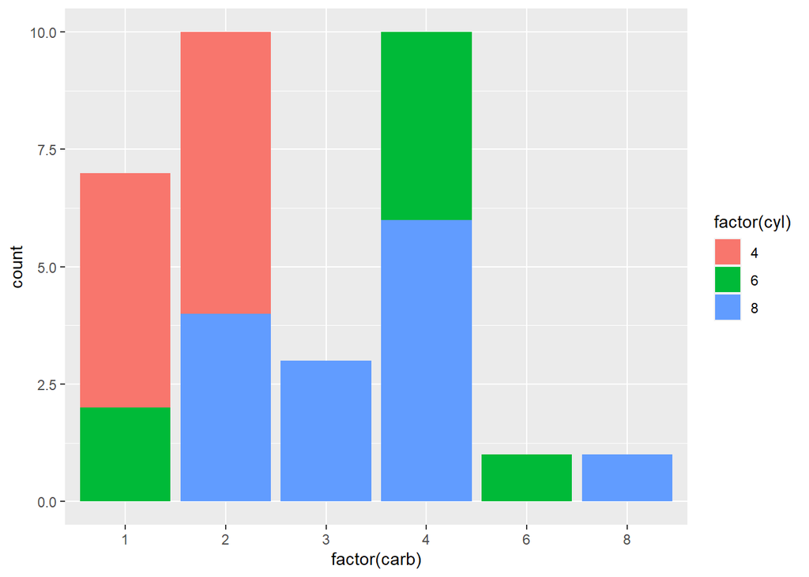

loading libs

```r
library(ggplot2)
ggplot(mtcars, aes(factor(carb), fill=factor(cyl))) + geom_bar()
```

### data visualisation

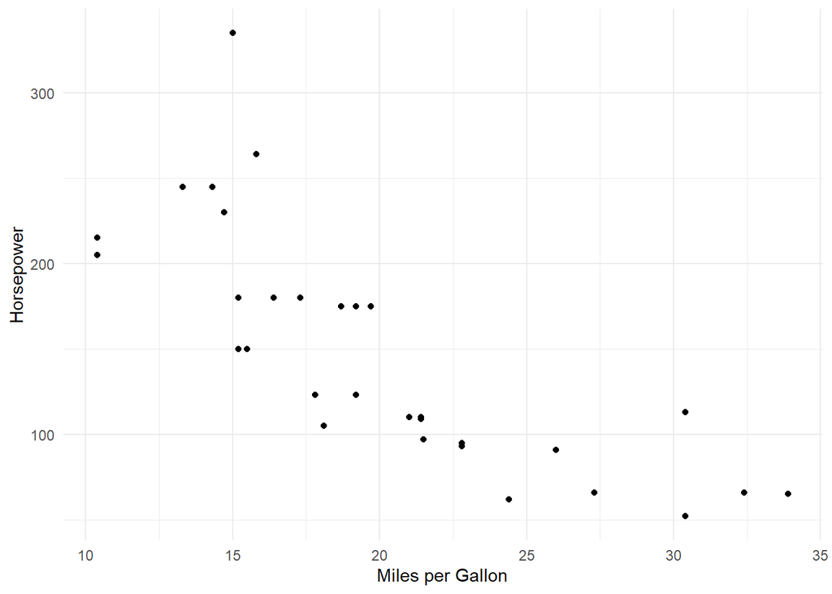

```r
ggplot(mtcars, aes(x=mpg, y=hp))+
  geom_point() +
  xlab("Miles per Gallon")+
  ylab("Horsepower")+
  theme_minimal()
```

## Modelling

```r
model <- lm(mpg~ hp, data = mtcars)
summary(model)
```

```
Call:
lm(formula = mpg ~ hp, data = mtcars)

Residuals:
    Min      1Q  Median      3Q     Max
-5.7121 -2.1122 -0.8854  1.5819  8.2360

Coefficients:
            Estimate Std. Error t value Pr(>|t|)
(Intercept) 30.09886    1.63392  18.421  < 2e-16 ***
hp          -0.06823    0.01012  -6.742 1.79e-07 ***
---
Signif. codes:  0 '***' 0.001 '**' 0.01 '*' 0.05 '.' 0.1 ' ' 1

Residual standard error: 3.863 on 30 degrees of freedom
Multiple R-squared:  0.6024,    Adjusted R-squared:  0.5892
F-statistic: 45.46 on 1 and 30 DF,  p-value: 1.788e-07
```

**Note**

Based on this model summary, the coefficient for **`hp`** is statistically significant (p-value < 0.001), indicating that there is a significant relationship between horsepower and miles per gallon. The negative coefficient (-0.06823) suggests that as horsepower increases, the miles per gallon tends to decrease.

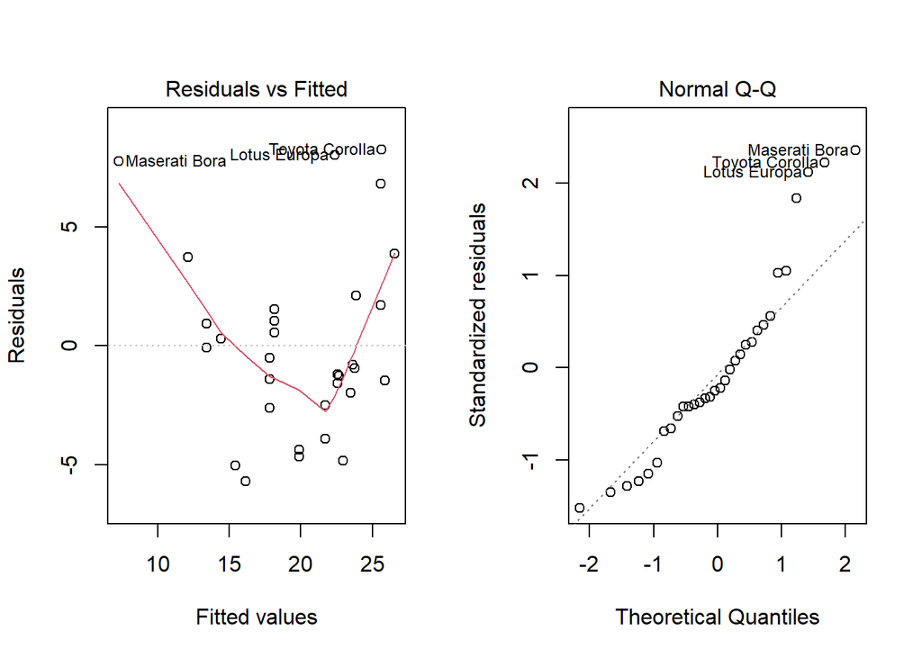

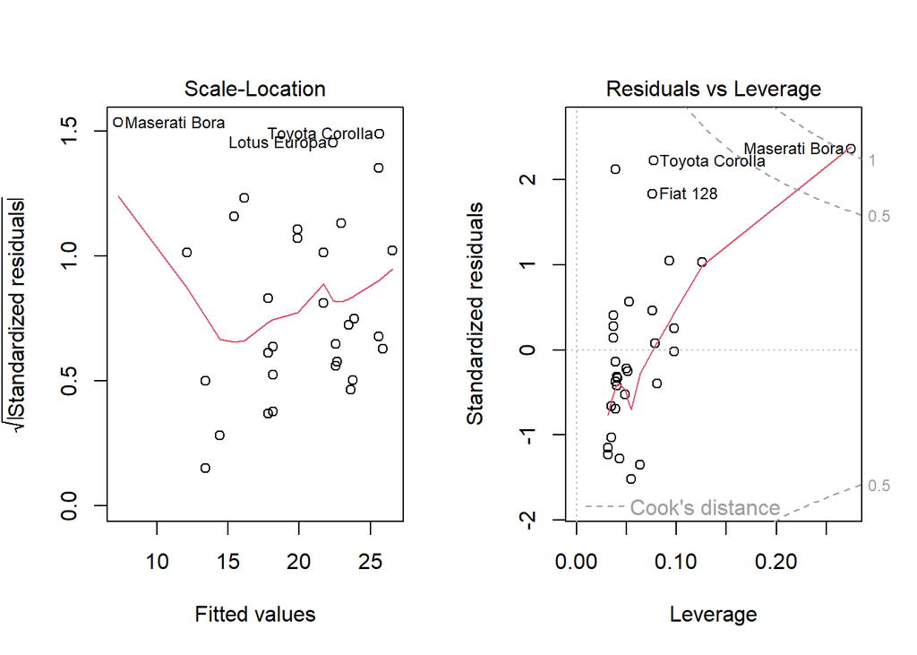

```r
par(mfrow = c(1,2))
plot(model)
```

```
Not enough model terms in the conditional part of the model to check for
  multicollinearity.
```

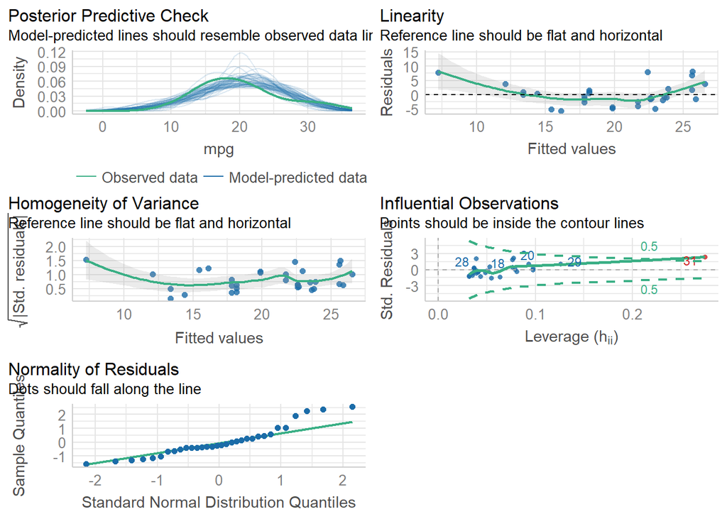

```r
library(performance)
library(see)
library(patchwork)
theme_set(theme_classic(base_size = 2))
check_model(model)
```

```r
check_outliers(model)
```

```
1 outlier detected: case 31.
- Based on the following method and threshold: cook (0.709).
- For variable: (Whole model).
```

```r
check_normality(model)
```

[output not shown]

```r
check_distribution(model)
```

```
# Distribution of Model Family

Predicted Distribution of Residuals

 Distribution Probability
       normal         53%
       cauchy         38%
      tweedie          6%

Predicted Distribution of Response

  Distribution Probability
       tweedie         44%
           chi         28%
 beta-binomial         16%
```

```r
model_1 <- lm(mpg ~hp + drat, data = mtcars)
summary(model_1)
```

```
Call:
lm(formula = mpg ~ hp + drat, data = mtcars)

Residuals:
    Min      1Q  Median      3Q     Max
-5.0369 -2.3487 -0.6034  1.1897  7.7500

Coefficients:
             Estimate Std. Error t value Pr(>|t|)
(Intercept) 10.789861   5.077752   2.125 0.042238 *
hp          -0.051787   0.009293  -5.573 5.17e-06 ***
drat         4.698158   1.191633   3.943 0.000467 ***
---
Signif. codes:  0 '***' 0.001 '**' 0.01 '*' 0.05 '.' 0.1 ' ' 1

Residual standard error: 3.17 on 29 degrees of freedom
Multiple R-squared:  0.7412,    Adjusted R-squared:  0.7233
F-statistic: 41.52 on 2 and 29 DF,  p-value: 3.081e-09
```

**tip**

1. Residuals: These are the differences between the observed **`mpg`** values and the predicted values from the model. The summary provides statistics such as the minimum, 1st quartile, median, 3rd quartile, and maximum values of the residuals.
2. Coefficients: The coefficients section presents the estimates, standard errors, t-values, and p-values for each predictor variable, as well as the intercept. Here’s the interpretation of the coefficients:
   - Intercept: The estimated intercept is 10.789861, indicating the expected value of **`mpg`** when both **`hp`** and **`drat`** are zero. The p-value (0.042238) suggests that the intercept is statistically significant at a significance level of 0.05.
   - **`hp`**: The estimated coefficient is -0.051787, indicating that, on average, each unit increase in horsepower (**`hp`**) is associated with a decrease of 0.051787 in the predicted **`mpg`** value. The low p-value (5.17e-06) suggests that this coefficient is statistically significant.
   - **`drat`**: The estimated coefficient is 4.698158, suggesting that, on average, each unit increase in the rear axle ratio (**`drat`**) is associated with an increase of 4.698158 in the predicted **`mpg`** value. The low p-value (0.000467) indicates that this coefficient is statistically significant.
3. Residual standard error: This value represents the estimated standard deviation of the residuals, indicating the average distance between the observed **`mpg`** values and the predicted values from the model.
4. Multiple R-squared and Adjusted R-squared: These values measure the goodness of fit of the model. The multiple R-squared represents the proportion of variance in the response variable (**`mpg`**) explained by the predictor variables (**`hp`** and **`drat`**). The adjusted R-squared takes into account the number of predictors and the sample size. In this case, the multiple R-squared is 0.7412, indicating that approximately 74.12% of the variability in **`mpg`** can be explained by the predictor variables in the model.
5. F-statistic and p-value: The F-statistic tests the overall significance of the model, comparing the variance explained by the model to the residual variance. The low p-value (3.081e-09) indicates that the model as a whole is statistically significant, suggesting that at least one of the predictor variables is significantly associated with the **`mpg`** values.

```r
check_outliers(model_1)
```

```
OK: No outliers detected.
- Based on the following method and threshold: cook (0.808).
- For variable: (Whole model)
```

```r
check_collinearity(model_1)
```

```
# Check for Multicollinearity

Low Correlation

 Term  VIF   VIF 95% CI Increased SE Tolerance Tolerance 95% CI
   hp 1.25 [1.04, 2.42]         1.12      0.80     [0.41, 0.96]
 drat 1.25 [1.04, 2.42]         1.12      0.80     [0.41, 0.96]
```

```r
check_distribution(model_1)
```

```
# Distribution of Model Family

Predicted Distribution of Residuals

 Distribution Probability
       normal         50%
       cauchy         41%
            F          3%

Predicted Distribution of Response

  Distribution Probability
       tweedie         44%
           chi         28%
 beta-binomial         16%
```

```r
check_normality(model_1)
```

[output not shown]

[figure not shown]

```r
check_predictions(model_1)
```

[figure not shown]

```r
check_posterior_predictions(model_1)
```